# Small Group Collaboration - Session 6

October 29, 2020

## Data Description

The data consist of the profiles of 59,946 OkCupid users who were living within 25 miles of San Francisco, had active profiles on June 26, 2012, were online in the previous year, and had at least one picture in their profile.

## Data Preview

```
## Rows: 59,946
## Columns: 22
## $ age         <int> 22, 35, 38, 23, 29, 29, 32, 31, 24, 37, 35, 28, 24, 30, 2…
## $ body_type   <chr> "a little extra", "average", "thin", "thin", "athletic", …
## $ diet        <chr> "strictly anything", "mostly other", "anything", "vegetar…
## $ drinks      <chr> "socially", "often", "socially", "socially", "socially", …
## $ drugs       <chr> "never", "sometimes", NA, NA, "never", NA, "never", "neve…
## $ education   <chr> "working on college/university", "working on space camp",…
## $ ethnicity   <chr> "asian, white", "white", NA, "white", "asian, black, othe…
## $ height      <int> 75, 70, 68, 71, 66, 67, 65, 65, 67, 65, 70, 72, 72, 66, 6…
## $ income      <int> NA, 80000, NA, 20000, NA, NA, NA, NA, NA, NA, NA, 40000, …
## $ job         <chr> "transportation", "hospitality / travel", NA, "student", …
## $ last_online <dttm> 2012-06-28 20:30:00, 2012-06-29 21:41:00, 2012-06-27 09:…
## $ location    <chr> "south san francisco, california", "oakland, california",…
## $ offspring   <chr> "doesn't have kids, but might want them", "doesn't have k…
## $ orientation <chr> "straight", "straight", "straight", "straight", "straight…
## $ pets        <chr> "likes dogs and likes cats", "likes dogs and likes cats",…
## $ religion    <chr> "agnosticism and very serious about it", "agnosticism but…
## $ sex         <chr> "m", "m", "m", "m", "m", "m", "f", "f", "f", "m", "m", "m…
## $ sign        <chr> "gemini", "cancer", "pisces but it doesn't matter", "pisc…
## $ smokes      <chr> "sometimes", "no", "no", "no", "no", "no", NA, "no", "whe…
## $ speaks      <chr> "english", "english (fluently), spanish (poorly), french …
## $ status      <chr> "single", "single", "available", "single", "single", "sin…
## $ essay0      <chr> "about me:    i would love to think that i was some some …
```

## Question of Interest

We’re interested in whether the mean `height` reported for individuals identifying as “male” differs by `orientation`.

i.e. Are the mean heights for users who identify as “male” and “straight” different from the mean heights for users who identify as “male” and “queer”?

**What hypotheses would you use for your null and alternative hypothesis?**

## Data Wrangling

- How would you create a dataset of only individuals who identified as “male”?
- Orientation was recorded as “gay”, “bisexual”, or “straight”. If we wanted to combine “gay” and “bisexual” into one level called “queer”, what tools would we use?

## Data Visualizaton

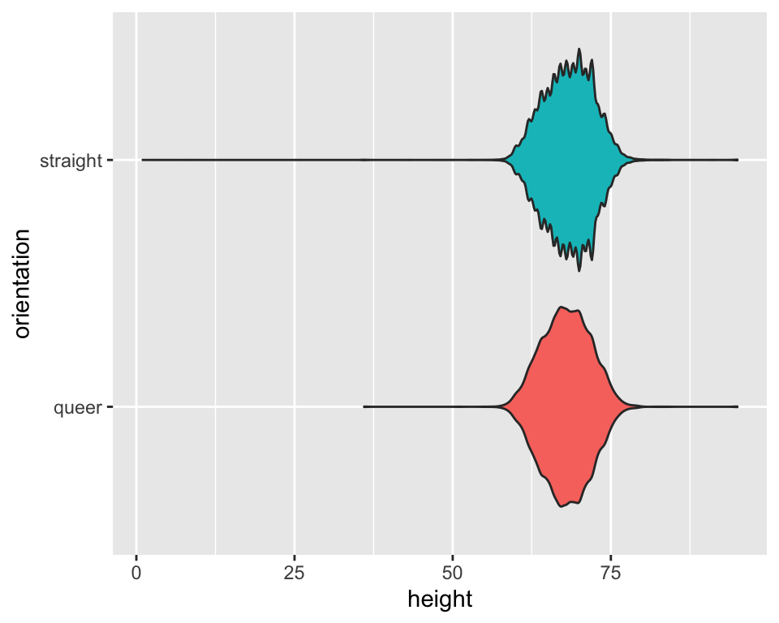

What do you notice about the distribution of heights between the two groups?

What units do you think `height` was reported in?

## Data Investigation

```
## # A tibble: 2 x 5
##   orientation min_height max_height median_height mean_height
##   <chr>            <int>      <int>         <dbl>       <dbl>
## 1 queer               36         95            68        68.0
## 2 straight             1         95            68        68.3
```

How would you filter out observations that had “ridiculous” values for `height`?

## Hypothesis Test

Below is a null distribution of permuted differences in means. What steps were used to generate this distribution?

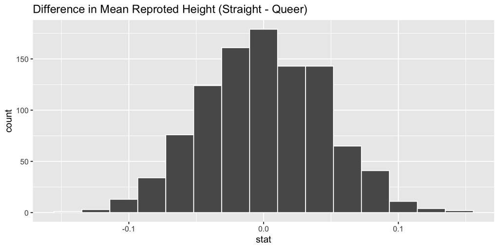

## Calculate the p-value

- Given the null distribution, how would you calculate the p-value for the hypothesis test?
- If there were no permuted difference in means as large as the one observed, what would you conclude?

## Different Questions

A hypothesis test lead us to conclude that the self-reported heights between users who identified as “male” and “straight” were different from users who identified as “male” and “queer”.

- What type of question would a confidence interval address?

## Bootstrap Distribution

To create a bootstrap distribution we no longer assume the null hypothesis is true.

- How does that change our process of generating new differences in means?

## Confidence Interval

Below is a bootstrap distribution for 1000 bootstrap resamples.

- Where is the distribution centered? Why is that the case?
- How would you use this distribution to create a 99% confidence interval for the difference in mean reported heights?

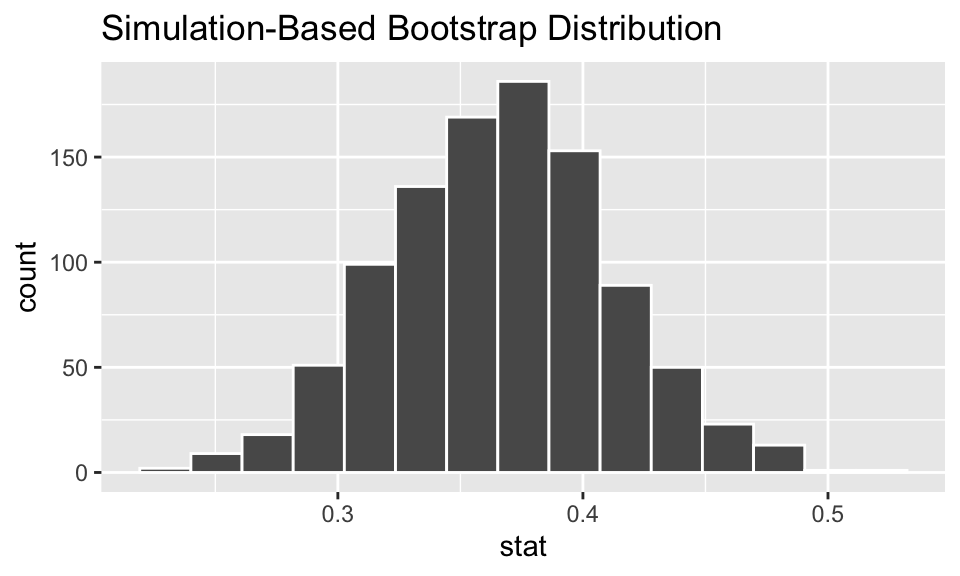

## Interpretting a Confidence Interval

The 99% confidence interval was calculated to be (0.252, 0.471).

- How would you interpret this interval?
- Does it seem like the difference in mean height between the two groups is really that different?
- Why then do you think the hypothesis test had a p-value of approximately 0?